# Working with `DataCombined` class

## Introduction

In Modeling and Simulation (M&S) workflows, we often need to work with multiple observed and/or simulated datasets. Further, some of these datasets can be linked together in a group (e.g., the simulated and the correnspoding observed data) for analysis and visualization.

The `DataCombined` class in `{ospsuite}` provides a container to store data, to group them, and to transform them further. The class accepts data coming from `SimulationResults` or as a `DataSet` object (see Observed data).

Let’s first generate some simulation results and load observed data.

```r
library(ospsuite)

# Simulation results
simFilePath <- system.file("extdata", "Aciclovir.pkml", package = "ospsuite")
sim <- loadSimulation(simFilePath)
simResults <- runSimulation(sim)
outputPath <- "Organism|PeripheralVenousBlood|Aciclovir|Plasma (Peripheral Venous Blood)"

# observed data
obsData <- lapply(
  c("ObsDataAciclovir_1.pkml", "ObsDataAciclovir_2.pkml", "ObsDataAciclovir_3.pkml"),
  function(x) loadDataSetFromPKML(system.file("extdata", x, package = "ospsuite"))
)
# Name the elements of the list according to the names of the loaded `DataSet`.
names(obsData) <- lapply(obsData, function(x) x$name)
```

Typically, `DataCombined` is used to create figures using the `plotXXX()` functions. The different plot types are described in Visualizations with `DataCombined`. To visualize the different functionalities of `DataCombined` in this document, we will use the `plotIndividualTimeProfile()` function.

## Creating `DataCombined` object

First, we create a new instance of `DataCombined` class.

```r
myDataCombined <- DataCombined$new()
```

Then we add simulated results to this object using `$addSimulationResults()`:

```r
myDataCombined$addSimulationResults(
  simulationResults = simResults,
  quantitiesOrPaths = outputPath,
  names = "Aciclovir Plasma",
  groups = "Aciclovir PVB"
)
```

Next we add observed data to this object using `$addDataSets()`:

```r
myDataCombined$addDataSets(
  obsData$`Vergin 1995.Iv`,
  groups = "Aciclovir PVB"
)
```

Every data, be it simulated results or from `DataSet`, must have a unique name within `DataCombined`. If not specified by user, the path of simulated results or the `$name` property of the `DataSet` are used as the name. Alternatively, we can define the name when adding the data, as in the above example adding simulated results.

There are a few things to keep in mind here:

- It doesn’t matter in which order observed or simulated datasets are added.
- You can add multiple `DataSet` objects in `$addDataSets()` method call.
- You can add only a single instance of `SimulationResults` in `$addSimulationResults()` method call.
- If you add a dataset with the same name as existing (e.g., adding simulation results from multiple simulations and not specifying the name, so the path of the results is used as the name), the new data will replace the existing.

## Grouping

Since the `DataCombined` object can store many datasets, some of them may naturally form a grouping and you would wish to track this in the object. Both `$addDataSets()` and `$addSimulationResults()` allow group specification via `groups` argument.

When being plotted, data sets without a grouping will appear with distinct color, line style (for simulated results), or symbol style (for observed data) with a separate entry in the legend, with the name of the data set being the legend entry.

Let’s create a `DataCombined` and add simulation results and observed data *without* specifying their grouping and create a time profile:

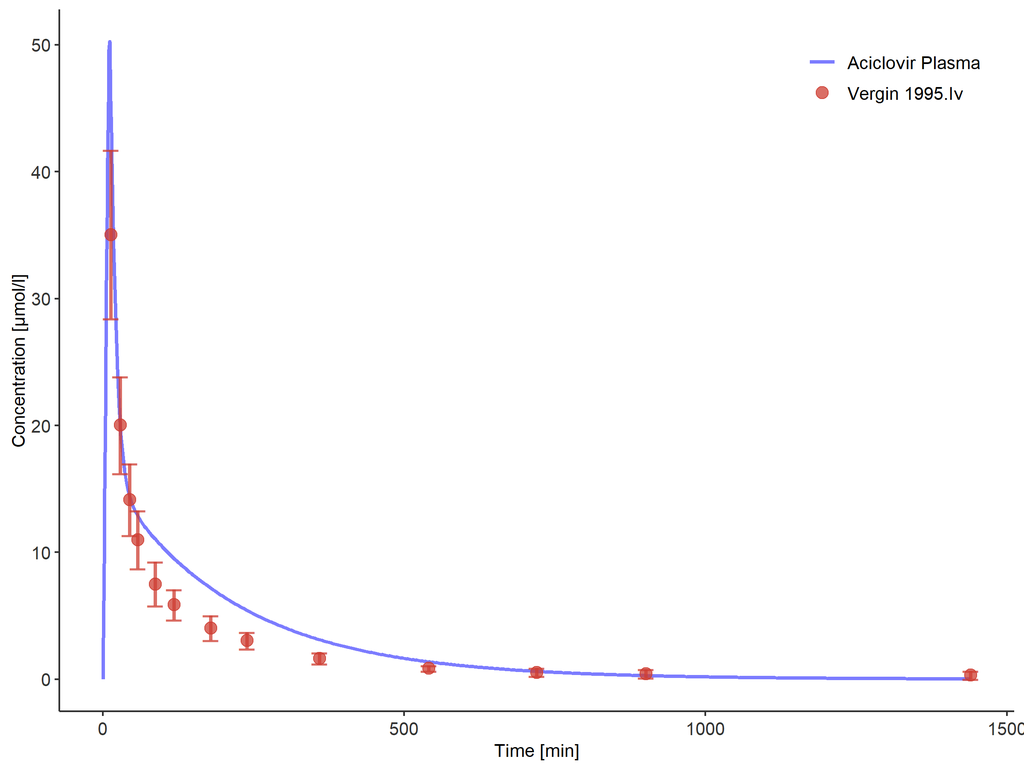

```r
myDataCombined <- DataCombined$new()

myDataCombined$addSimulationResults(
  simulationResults = simResults,
  quantitiesOrPaths = outputPath,
  names = "Aciclovir Plasma"
)

myDataCombined$addDataSets(
  obsData$`Vergin 1995.Iv`
)

plotIndividualTimeProfile(dataCombined = myDataCombined)
```

If you do not specify `groups` when you add datasets or set it to `NULL`, and wish to update groupings later, you can use the `$setGroups()` method. All data within one group will get one entry in the legend with the name of the group, and will be plotted with the same color.

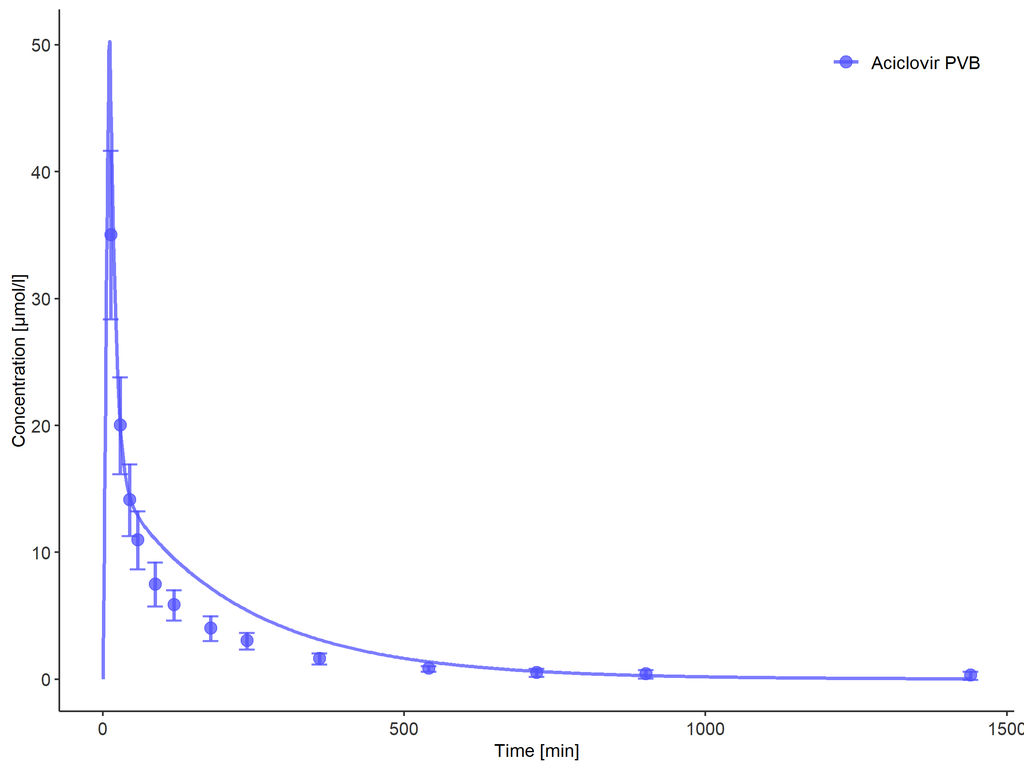

```r
myDataCombined$setGroups(names = c("Aciclovir Plasma", obsData$`Vergin 1995.Iv`$name),
                         groups = "Aciclovir PVB")

plotIndividualTimeProfile(dataCombined = myDataCombined)
```

At any point, you can check the current names and groupings with the following active field:

```r
myDataCombined$groupMap
```

```
#> # A tibble: 2 × 3
#>   group         name             dataType
#>   <chr>         <chr>            <chr>
#> 1 Aciclovir PVB Aciclovir Plasma simulated
#> 2 Aciclovir PVB Vergin 1995.Iv   observed
```

## Transformations

Sometimes the raw data included in `DataCombined` needs to be transformed using specified offset and scale factor values.

This is supported via `$setDataTransformations()` method, where you can specify the names of datasets, and offsets and scale factors. If these arguments are scalar (i.e., of length 1), then the same value will be applied to all specified names.

The internal data frame in `DataCombined` will be transformed with the specified parameters, with the new columns computed as:

- For x values: `newXValue = (rawXValue + xOffset) * xScaleFactor`
- For y values: `newYValue = (rawYValue + yOffset) * yScaleFactor`
- For arithmetic error: `newErrorValue = rawErrorValue * scaleFactor`
- For geometric errir: no transformation.

At any point, you can check the applied offsets and scale factors with the following active field:

```r
myDataCombined$dataTransformations
```

```
#> # A tibble: 2 × 5
#>   name             xOffsets yOffsets xScaleFactors yScaleFactors
#>   <chr>               <dbl>    <dbl>         <dbl>         <dbl>
#> 1 Aciclovir Plasma        0        0             1             1
#> 2 Vergin 1995.Iv          0        0             1             1
```

Now lets take a closer look on possible situations where you would apply any transformations. Consider the obssrved data from the examples above. It reports concentrations of aciclovir after single intravenous administration.

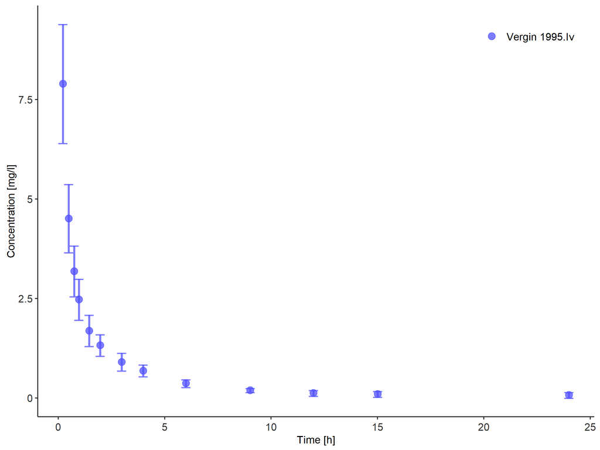

```r
myDataCombinedTranformations <- DataCombined$new()

myDataCombinedTranformations$addDataSets(
  obsData$`Vergin 1995.Iv`
)

plotIndividualTimeProfile(dataCombined = myDataCombinedTranformations)
```

However, we might want to use this data set with a simulation where aciclovir is administered 24 hours after simulation begin. To be able to compare simulation results with the data set, we can *offset* the observed data time by 24 hours. Keep in mind that the offset must be given in the same unit as the data set values are.

```r
# Check the units of the observed time values
obsData$`Vergin 1995.Iv`$xUnit
```

```
#> [1] "h"
```

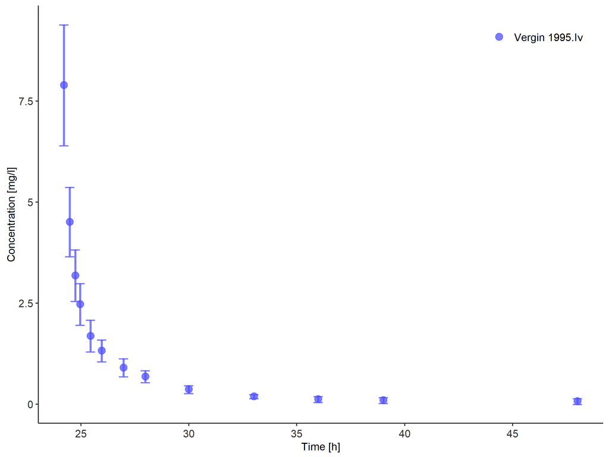

```r
myDataCombinedTranformations$setDataTransformations(forNames = obsData$`Vergin 1995.Iv`$name,
                                      xOffsets = 24)

plotIndividualTimeProfile(dataCombined = myDataCombinedTranformations)
```

In the next step, we want to *normalize* observed concentrations to a dose. We can easily achieve this with the scale factor. In the next example, we normalize observed values to 250 mg dose by setting the `yScaleFactor` to 1/250:

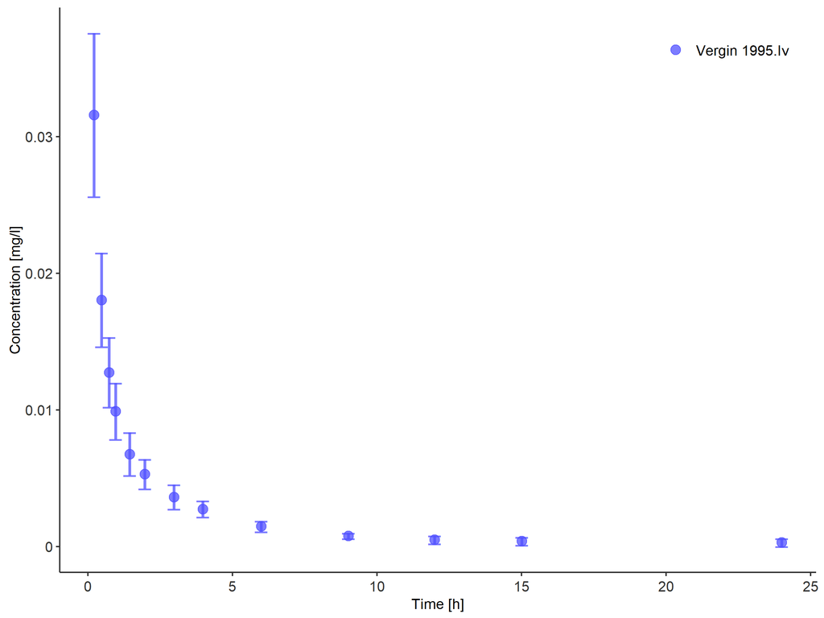

```r
myDataCombinedTranformations$setDataTransformations(forNames = obsData$`Vergin 1995.Iv`$name,
                                      yScaleFactors = 1/250)

plotIndividualTimeProfile(dataCombined = myDataCombinedTranformations)
```

Finally, offsetting the observation values might be useful when working with measurements of endogenous substrates, such as the hormone glucogen, and want to correct for the individual specific baseline levels of the hormone.

## Extracting a combined data frame

The data frame (also sometimes called as a table) data structure is central to R-based workflows, and, thus, we may wish to extract a data frame for datasets present in the object.

Internally, `DataCombined` extracts data frames for observed and simulated datasets and combines them.

```r
myDataCombined$toDataFrame()
```

```
#> # A tibble: 504 × 27
#>    name        group dataT…¹ xValues xUnit xDime…² yValues yUnit yDime…³ yErro…⁴
#>    <chr>       <chr> <chr>     <dbl> <chr> <chr>     <dbl> <chr> <chr>     <dbl>
#>  1 Aciclovir … Acic… simula…       0 min   Time       0    µmol… Concen…      NA
#>  2 Aciclovir … Acic… simula…       1 min   Time       3.25 µmol… Concen…      NA
#>  3 Aciclovir … Acic… simula…       2 min   Time       9.10 µmol… Concen…      NA
#>  4 Aciclovir … Acic… simula…       3 min   Time      15.0  µmol… Concen…      NA
#>  5 Aciclovir … Acic… simula…       4 min   Time      20.7  µmol… Concen…      NA
#>  6 Aciclovir … Acic… simula…       5 min   Time      26.2  µmol… Concen…      NA
#>  7 Aciclovir … Acic… simula…       6 min   Time      31.4  µmol… Concen…      NA
#>  8 Aciclovir … Acic… simula…       7 min   Time      36.4  µmol… Concen…      NA
#>  9 Aciclovir … Acic… simula…       8 min   Time      41.1  µmol… Concen…      NA
#> 10 Aciclovir … Acic… simula…       9 min   Time      45.5  µmol… Concen…      NA
#> # … with 494 more rows, 17 more variables: yErrorType <chr>, yErrorUnit <chr>,
#> #   IndividualId <int>, molWeight <dbl>, lloq <dbl>, Source <chr>, File <chr>,
#> #   Sheet <chr>, Molecule <chr>, Species <chr>, Organ <chr>, Compartment <chr>,
#> #   `Study Id` <chr>, Gender <chr>, Dose <chr>, Route <chr>,
#> #   `Patient Id` <chr>, and abbreviated variable names ¹dataType, ²xDimension,
#> #   ³yDimension, ⁴yErrorValues
```

This function returns a [tibble data frame](https://r4ds.had.co.nz/tibbles.html#tibbles-vs.-data.frame). If you wish to modify how it is printed, you can have a look at the available options [here](https://pillar.r-lib.org/reference/pillar_options.html). In fact, let’s change a few options and print the data frame again.

```r
options(
  pillar.width = Inf, # show all columns
  pillar.min_chars = Inf # to turn off truncation of column titles
)

myDataCombined$toDataFrame()
```

```
#> # A tibble: 504 × 27
#>    name             group         dataType  xValues xUnit xDimension yValues
#>    <chr>            <chr>         <chr>       <dbl> <chr> <chr>        <dbl>
#>  1 Aciclovir Plasma Aciclovir PVB simulated       0 min   Time          0
#>  2 Aciclovir Plasma Aciclovir PVB simulated       1 min   Time          3.25
#>  3 Aciclovir Plasma Aciclovir PVB simulated       2 min   Time          9.10
#>  4 Aciclovir Plasma Aciclovir PVB simulated       3 min   Time         15.0
#>  5 Aciclovir Plasma Aciclovir PVB simulated       4 min   Time         20.7
#>  6 Aciclovir Plasma Aciclovir PVB simulated       5 min   Time         26.2
#>  7 Aciclovir Plasma Aciclovir PVB simulated       6 min   Time         31.4
#>  8 Aciclovir Plasma Aciclovir PVB simulated       7 min   Time         36.4
#>  9 Aciclovir Plasma Aciclovir PVB simulated       8 min   Time         41.1
#> 10 Aciclovir Plasma Aciclovir PVB simulated       9 min   Time         45.5
#>    yUnit  yDimension            yErrorValues yErrorType yErrorUnit IndividualId
#>    <chr>  <chr>                        <dbl> <chr>      <chr>             <int>
```

[output cut: 35 more lines]

As can be seen, this data frame attemtps to provide a one-stop access to all important details about the datasets included in the object, including important meta-data.

`{ospsuite}` also provides a few helper functions to modify the data frame further.

When multiple (observed and/or simulated) datasets are present in a data frame, they are likely to have different units. `convertUnits()` function helps to convert them to a common unit[^1].

```r
convertUnits(
  myDataCombined,
  xUnit = ospUnits$Time$s,
  yUnit = ospUnits$`Concentration [mass]`$`µg/l`
)
```

```
#> # A tibble: 504 × 27
#>    name        group dataT…¹ xValues xUnit xDime…² yValues yUnit yDime…³ yErro…⁴
#>    <chr>       <chr> <chr>     <dbl> <chr> <chr>     <dbl> <chr> <chr>     <dbl>
#>  1 Aciclovir … Acic… simula…       0 s     Time         0  µg/l  Concen…      NA
#>  2 Aciclovir … Acic… simula…      60 s     Time       733. µg/l  Concen…      NA
#>  3 Aciclovir … Acic… simula…     120 s     Time      2050. µg/l  Concen…      NA
#>  4 Aciclovir … Acic… simula…     180 s     Time      3382. µg/l  Concen…      NA
#>  5 Aciclovir … Acic… simula…     240 s     Time      4668. µg/l  Concen…      NA
#>  6 Aciclovir … Acic… simula…     300 s     Time      5901. µg/l  Concen…      NA
#>  7 Aciclovir … Acic… simula…     360 s     Time      7077. µg/l  Concen…      NA
#>  8 Aciclovir … Acic… simula…     420 s     Time      8194. µg/l  Concen…      NA
#>  9 Aciclovir … Acic… simula…     480 s     Time      9249. µg/l  Concen…      NA
#> 10 Aciclovir … Acic… simula…     540 s     Time     10242. µg/l  Concen…      NA
#> # … with 494 more rows, 17 more variables: yErrorType <chr>, yErrorUnit <chr>,
#> #   IndividualId <int>, molWeight <dbl>, lloq <dbl>, Source <chr>, File <chr>,
#> #   Sheet <chr>, Molecule <chr>, Species <chr>, Organ <chr>, Compartment <chr>,
#> #   `Study Id` <chr>, Gender <chr>, Dose <chr>, Route <chr>,
#> #   `Patient Id` <chr>, and abbreviated variable names ¹dataType, ²xDimension,
#> #   ³yDimension, ⁴yErrorValues
```

## Further functionalities

Grouping of simulated results with observed data inside `DataCombined` also allows to calculate the error between simulated results and observations using the `calculateResiduals()` function. The function calculates the distance between each observed data point within the group and the simulated results. Simulation results interpolated if no simulated value is available for a certain observed time point.

There are two ways to calculate the distance (residuals) - linear and logarithmic - specified by the `scaling` argument. For linear scaling (`scaling = tlf::Scaling$lin`):

> Residuals are calculated as: Simulation value - Observed value. This means that the residuals are defined by absolute differences.

For logarithmic scaling (`scaling = tlf::Scaling$log`):

> Residuals are calculated as: log(Simulation value) - log(Observed value) = log (Simulation Value / Observed Value). This means that the ratio of values is considered which is independent of the magnitude of the value. But for very small observed values, in particular close to 0 values, this can lead to problems, because log(10E-N) = -N can becomes large.

```r
#Linear residuals
calculateResiduals(myDataCombined, scaling = tlf::Scaling$lin)$residualValues
```

```
#>  [1] 10.52672990 -0.83260579  0.13009016  1.93634422  3.53626939  3.57509463
#>  [7]  3.11918158  2.36516686  1.48703530  0.51219212  0.08009793 -0.14757315
#> [13] -0.29395086
```

```r
#Logarithmic residuals
calculateResiduals(myDataCombined, scaling = tlf::Scaling$log)$residualValues
```

```
#>  [1]  0.262664210 -0.042467679  0.009152926  0.162255502  0.385885711
#>  [6]  0.475198572  0.573584398  0.574454058  0.647582143  0.462657397
#> [11]  0.137321647 -0.413996094 -2.305882655
```

To quickly calculate the total error of the `DataCombined`, one can sum up the absolute values of the residulas:

```r
#Linear residuals
totalError <- sum(abs(calculateResiduals(myDataCombined, scaling = tlf::Scaling$lin)$residualValues))

print(totalError)
```

```
#> [1] 28.54233
```

## Visualizations with `DataCombined`

Plotting the stored data is an important part of model diagnostics and quality control.

See Visualizations with `DataCombined` describing functions that can visualize data stored in `DataCombined` object.

[^1]: Note that if you are using `DataCombined` object for plotting functions, you don’t need to this conversion; the plotting functions will take care of this internally.